# 量化交易

## 量化交易 101 和向量化回测

## 目录

### 1. **基于简单移动均线策略**

1. 特殊示例
2. 通用示例

### 2. **基于动量策略**

1. 特殊示例
2. 通用示例

### 3. **基于均值回归策略**

1. 特殊示例
2. 通用示例

### 本课的主要目标是掌握向量化回测 (vectorized backtesting) 实现方法，内容包括：

### 交互式策略探索

- 该方法敏捷而且能交互性强，一般几行代码就能够快速得到结果，并且可以轻松测试不同的参数组合。

### 可视化作为主要目标

- 该方法非常适合用于可视化使用数据、统计结果、交易信号和性能指标。

### 综合回测程序

- 该方法总体上非常快，允许测试多种短时间内的参数组合。当速度是关键因素时，应该考虑此方法。

### 本课介绍了应用于三种类型的交易策略的回测：

- **基于简单移动均线** **(Simple Moving Average)**
- **基于动量** **(Momentum)**
- **基于均值回归** **(Mean Reversion)**

```python
import numpy as np
import pandas as pd

import matplotlib as mpl
import matplotlib.pyplot as plt
import seaborn as sns
plt.style.use('ggplot')
mpl.rcParams['figure.dpi'] = 100
mpl.rcParams['savefig.dpi'] = 300
```

# 1. 基于简单移动均线策略

回到目录

基于**简单移动均线 (Simple Moving Average, SMA)** 的交易是一种已有数十年历史的策略，其起源于技术股票分析领域。

### 1.1 特殊示例

回到章首

本小节重点介绍使用两个 SMA 的回测交易策略的基础知识，下面的示例用欧元/美元 (EURUSD) 汇率从 2010 年到 2019 年的 10 年日终 (EOD) 收盘数据。

```python
raw = pd.read_csv('eod_data.csv', index_col=0, parse_dates=True).dropna()
raw.info()
```

```
<class 'pandas.core.frame.DataFrame'>
DatetimeIndex: 2516 entries, 2010-01-04 to 2019-12-31
Data columns (total 12 columns):
 #   Column  Non-Null Count  Dtype
---  ------  --------------  -----
 0   AAPL.O  2516 non-null   float64
 1   MSFT.O  2516 non-null   float64
 2   INTC.O  2516 non-null   float64
 3   AMZN.O  2516 non-null   float64
 4   GS.N    2516 non-null   float64
 5   SPY     2516 non-null   float64
 6   .SPX    2516 non-null   float64
 7   .VIX    2516 non-null   float64
 8   EUR=    2516 non-null   float64
 9   XAU=    2516 non-null   float64
 10  GDX     2516 non-null   float64
 11  GLD     2516 non-null   float64
dtypes: float64(12)
memory usage: 255.5 KB
```

```python
data = pd.DataFrame(raw['EUR='])
data.rename(columns={'EUR=': 'price'}, inplace=True)
data.info()
```

```
<class 'pandas.core.frame.DataFrame'>
DatetimeIndex: 2516 entries, 2010-01-04 to 2019-12-31
Data columns (total 1 columns):
 #   Column  Non-Null Count  Dtype
---  ------  --------------  -----
 0   price   2516 non-null   float64
dtypes: float64(1)
memory usage: 39.3 KB
```

SMA 的计算通过 **`Pandas`** 包里的 `rolling()` 函数变得简单：

```python
data['SMA1'] = data['price'].rolling(42).mean()
data['SMA2'] = data['price'].rolling(252).mean()
data.head(3).append(data.tail(3))
```

| Date | price | SMA1 | SMA2 |
| --- | --- | --- | --- |
| 2010-01-04 | 1.4411 | NaN | NaN |
| 2010-01-05 | 1.4368 | NaN | NaN |
| 2010-01-06 | 1.4412 | NaN | NaN |
| 2019-12-27 | 1.1175 | 1.107924 | 1.119428 |
| 2019-12-30 | 1.1197 | 1.108131 | 1.119333 |
| 2019-12-31 | 1.1210 | 1.108279 | 1.119231 |

第一行创建一个包含 42 天 SMA 值的列，前 41 个值将是 NaN。第二行创建一个包含 252 天 SMA 值的列，前 251 个值将是 NaN。

将原始时间序列 Price 数据与两个 SMA 相结合做可视化。

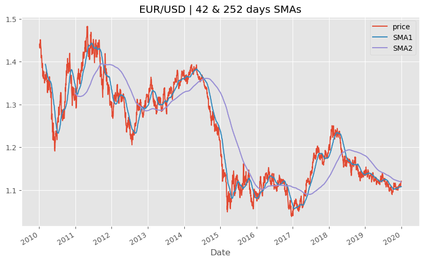

```python
data.plot(title='EUR/USD | 42 & 252 days SMAs', figsize=(10, 6));
```

以向量化方式来生成交易规则，用 `np.where()` 函数来评估表达式 `data['SMA1'] > data['SMA2']`，对于数据每行，当其为 **`True`** 时产生 +1，当其为 **`False`** 时产生 -1。最后删除数据集中包含 NaN 值的所有行。

```python
data['position'] = np.where(data['SMA1'] > data['SMA2'], 1, -1)
data.dropna(inplace=True)
```

画出随着时间的组合头寸。

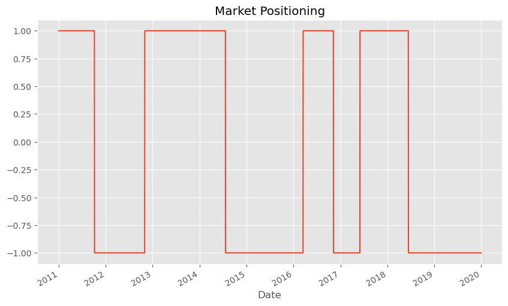

```python
data['position'].plot(ylim=[-1.1, 1.1], title='Market Positioning', figsize=(10, 6));
```

要计算策略的性能指标，首先要计算对数收益。

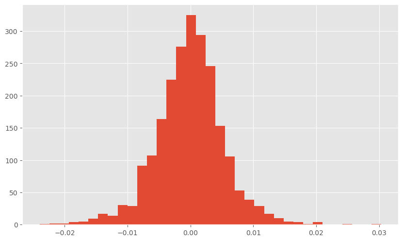

```python
data['returns'] = np.log(data['price'] / data['price'].shift(1))
data['returns'].hist(bins=35, figsize=(10, 6));
```

要得出策略收益，将头寸列（移动一个交易日，用 `shift(1)`）与收益列相乘。由于对数收益是可加的，给定时点 $0 = t_0 < t_1 < t_2 < \cdots < t_{n-1} < t_n = T$

\begin{align} R(0,T) = R(0,t_1) + R(t_1,t_2) + \cdots + R(t_{n-1},T) \end{align}

因为

\begin{align} \text{ln}\frac{S(T)}{S(0)} = \text{ln}\left(\frac{S(t_1)}{S(0)}\cdot\frac{S(t_2)}{S(t_1)}\cdots \frac{S(T)}{S(t_{n-1})}\right) = \text{ln}\frac{S(t_1)}{S(0)} + \text{ln}\frac{S(t_2)}{S(t_1)} + \cdots + \text{ln}\frac{S(T)}{S(t_{n-1})} \end{align}

计算收益 (returns) 和策略 (strategy) 列总和，并比对策略对数总收益和基准对数总收益。

```python
data['strategy'] = data['position'].shift(1) * data['returns']
```

```python
data[['returns', 'strategy']].sum()
```

```
returns    -0.176731
strategy    0.253121
dtype: float64
```

用指数函数 `np.exp` 应用于对数收益的总和可以计算总绩效。

\begin{align} \text{exp}\left(\text{ln}\frac{S(T)}{S(0)}\right) = \frac{S(T)}{S(0)} \end{align}

```python
data[['returns', 'strategy']].sum().apply(np.exp)
```

```
returns     0.838006
strategy    1.288039
dtype: float64
```

使用 `cumsum()` 计算一段时间内的累积总和，并在此基础上通过应用指数函数 `np.exp()` 计算累积收益，可以更全面地了解和比较策略收益与基准收益。对于时点 $t_i$

\begin{align} \text{exp}\left(\text{ln}\frac{S(t_i)}{S(0)}\right) = \frac{S(t_i)}{S(0)} \end{align}

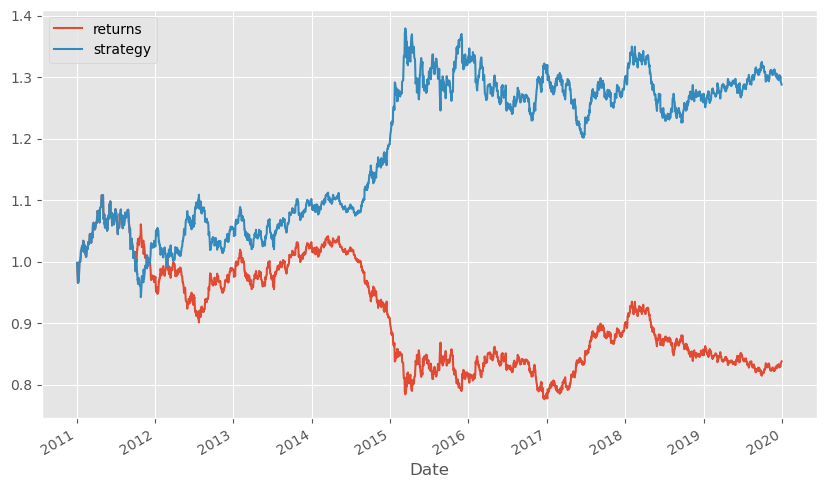

```python
data[['returns', 'strategy']].cumsum().apply(np.exp).plot(figsize=(10, 6));
```

策略和基准的平均年化收益和风险指标（对数和常规形式）很容易计算，给定时点 $0 = t_0 < t_1 < t_2 < \cdots < t_{n-1} < t_n = T$

### 平均年化对数收益

\begin{align} \bar{R} = \frac{R(t_0,t_1) + R(t_1,t_2) + \cdots + R(t_{n-1},t_n)}{n} \times 252 \end{align}

```python
data[['returns', 'strategy']].mean() * 252
```

```
returns    -0.019671
strategy    0.028174
dtype: float64
```

### 平均年化收益

\begin{align} \bar{r} = \text{exp}\left(\frac{R(t_0,t_1) + R(t_1,t_2) + \cdots + R(t_{n-1},t_n)}{n} \times 252\right) - 1 \end{align}

```python
np.exp(data[['returns', 'strategy']].mean() * 252) - 1
```

```
returns    -0.019479
strategy    0.028575
dtype: float64
```

### 平均年化对数波动率

```python
data[['returns', 'strategy']].std() * 252 ** 0.5
```

```
returns     0.085414
strategy    0.085405
dtype: float64
```

### 平均年化波动率

```python
(data[['returns', 'strategy']].apply(np.exp) - 1).std() * 252 ** 0.5
```

```
returns     0.085405
strategy    0.085373
dtype: float64
```

在交易策略表现的背景下，通常感兴趣的其他风险指标是**最大回撤** (maximum drawdown) 和**最长回撤期** (longest drawdown period)，用 函数 `cummax()` 可以计算策略的累积最大总收益。

### 最大回撤

定义一个新列 `cumret`，其中包含每个时点上的策略总收益。

```python
data['cumret'] = data['strategy'].cumsum().apply(np.exp)
data
```

| Date | price | SMA1 | SMA2 | position | returns | strategy | cumret |
| --- | --- | --- | --- | --- | --- | --- | --- |
| 2010-12-31 | 1.3377 | 1.342579 | 1.326218 | 1 | NaN | NaN | NaN |
| 2011-01-03 | 1.3351 | 1.340945 | 1.325798 | 1 | -0.001946 | -0.001946 | 0.998056 |
| 2011-01-04 | 1.3301 | 1.338940 | 1.325374 | 1 | -0.003752 | -0.003752 | 0.994319 |
| 2011-01-05 | 1.3151 | 1.336448 | 1.324874 | 1 | -0.011341 | -0.011341 | 0.983105 |
| 2011-01-06 | 1.3001 | 1.333995 | 1.324351 | 1 | -0.011472 | -0.011472 | 0.971892 |
| ... | ... | ... | ... | ... | ... | ... | ... |
| 2019-12-24 | 1.1087 | 1.107698 | 1.119630 | -1 | 0.000090 | -0.000090 | 1.302328 |
| 2019-12-26 | 1.1096 | 1.107740 | 1.119529 | -1 | 0.000811 | -0.000811 | 1.301272 |
| 2019-12-27 | 1.1175 | 1.107924 | 1.119428 | -1 | 0.007094 | -0.007094 | 1.292073 |
| 2019-12-30 | 1.1197 | 1.108131 | 1.119333 | -1 | 0.001967 | -0.001967 | 1.289534 |
| 2019-12-31 | 1.1210 | 1.108279 | 1.119231 | -1 | 0.001160 | -0.001160 | 1.288039 |

2265 rows × 7 columns

定义另一列 `cummax`，其中包含每个时点上策略总收益的最大值。

```python
data['cummax'] = data['cumret'].cummax()
data
```

| Date | price | SMA1 | SMA2 | position | returns | strategy | cumret | cummax |
| --- | --- | --- | --- | --- | --- | --- | --- | --- |
| 2010-12-31 | 1.3377 | 1.342579 | 1.326218 | 1 | NaN | NaN | NaN | NaN |
| 2011-01-03 | 1.3351 | 1.340945 | 1.325798 | 1 | -0.001946 | -0.001946 | 0.998056 | 0.998056 |
| 2011-01-04 | 1.3301 | 1.338940 | 1.325374 | 1 | -0.003752 | -0.003752 | 0.994319 | 0.998056 |
| 2011-01-05 | 1.3151 | 1.336448 | 1.324874 | 1 | -0.011341 | -0.011341 | 0.983105 | 0.998056 |
| 2011-01-06 | 1.3001 | 1.333995 | 1.324351 | 1 | -0.011472 | -0.011472 | 0.971892 | 0.998056 |
| ... | ... | ... | ... | ... | ... | ... | ... | ... |
| 2019-12-24 | 1.1087 | 1.107698 | 1.119630 | -1 | 0.000090 | -0.000090 | 1.302328 | 1.379350 |
| 2019-12-26 | 1.1096 | 1.107740 | 1.119529 | -1 | 0.000811 | -0.000811 | 1.301272 | 1.379350 |
| 2019-12-27 | 1.1175 | 1.107924 | 1.119428 | -1 | 0.007094 | -0.007094 | 1.292073 | 1.379350 |
| 2019-12-30 | 1.1197 | 1.108131 | 1.119333 | -1 | 0.001967 | -0.001967 | 1.289534 | 1.379350 |
| 2019-12-31 | 1.1210 | 1.108279 | 1.119231 | -1 | 0.001160 | -0.001160 | 1.288039 | 1.379350 |

2265 rows × 8 columns

可视化 `cumret` 和 `cummax` 两列。

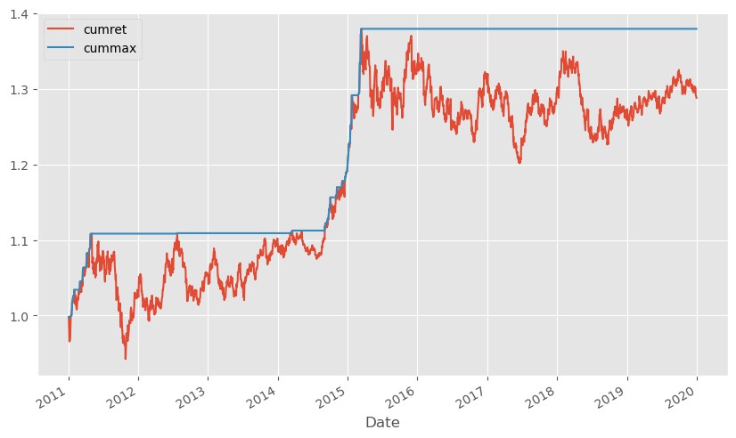

```python
data[['cumret', 'cummax']].dropna().plot(figsize=(10, 6));
```

计算最大回撤，即 `cummax` 和 `cumret` 列之间差异的最大值。示例中的最大回撤约为 18 个百分点：

```python
drawdown = data['cummax'] - data['cumret']
drawdown
```

```
Date
2010-12-31         NaN
2011-01-03    0.000000
2011-01-04    0.003738
2011-01-05    0.014951
2011-01-06    0.026164
                ...
2019-12-24    0.077022
2019-12-26    0.078078
2019-12-27    0.087278
2019-12-30    0.089816
2019-12-31    0.091312
Length: 2265, dtype: float64
```

```python
drawdown.max()
```

```
0.17779367070195917
```

### 最长回撤期

最长回撤期要求策略总收益等于其累积最大值的那些日期。此信息存储在临时对象中，然后计算所有这些日期之间的天数差异，并挑选出最长的时间段。计算得到最长回撤期持续了 596 天，相当长的一段时间。

```python
# 找到回撤为零的数据，即“累计收益”和“累计最大收益”相等的数据
temp = drawdown[drawdown == 0]

# 计算每个间隔的天数
periods = (temp.index[1:].to_pydatetime() - temp.index[:-1].to_pydatetime())

# 找到间隔的最大值
periods.max()
```

```
datetime.timedelta(days=596)
```

```python
#drawdown.dropna().plot(figsize=(10, 6));
```

### 1.2 通用示例

回到章首

上节代码可以解决实际问题，但是比较零散。本节将上节实施的函数整理成一个类，命名为 **`SMAVectorBacktester`**，顾名思义用于对 SMA 策略的向量化回测。该类的参数如下：

- `symbol`：RIC 代号
- `SMA1`：对于较短 SMA 的时间窗口（以天为单位）
- `SMA2`：对于较长 SMA 的时间窗口（以天为单位）
- `start`：要获取数据的开始日期
- `end`：要获取数据的结束日期

应用程序本身最好通过使用该类的交互式会话来说明。该示例

- 首先复制了上节基于 EUR/USD 汇率数据实施的回溯测试
- 然后优化 SMA 参数以获得最大的总体性能
- 最后基于最佳参数，绘制了在相关时间段内的策略收益与基准收益

首先引入 `SMAVectorBacktester` 赋予别名 `SMA`，在创建一个对象命名为 `smabt`。

```python
import SMAVectorBacktester as SMA

smabt = SMA.SMAVectorBacktester('EUR=', 42, 252, '2010-1-1', '2019-12-31')
```

给定实例化的五个参数，回测基于 SMA 的策略。结果是个元组，第 1 个元素代表策略绝对收益，第 2 个元素代表策略相对收益。

```python
smabt.run_strategy()
```

```
(1.29, 0.45)
```

用 `optimize_parameters()` 方法将步长作为输入参数，在本例中：

- `SMA1` 的范围从 30 到 50，按步长 2 递增
- `SMA2` 的范围从 200 到 300，按步长 2 递增

并通过蛮力法确定最佳参数组合 `(SMA1, SMA2) = (48, 238)`。

```python
%%time
smabt.optimize_parameters((30, 50, 2), (200, 300, 2))
```

```
Wall time: 11.1 s
```

```
(array([ 48., 238.]), 1.5)
```

给定当前存储的最优参数值，`plot_results()` 方法绘制策略表现与基准表现。

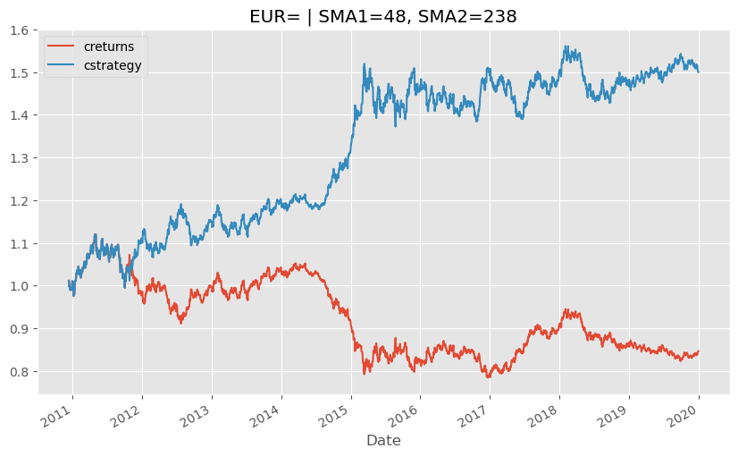

```python
smabt.plot_results()
```

# 2. 基于动量策略

回到目录

**动量** (momentum) 策略有两种基本类型：

- **横截面 (cross-sectional) 动量策略**：给定时点比较不同资产表现。该策略从更大的资产池中选择，购买最近表现优于同行的资产，并出售表现不佳的工具。基本思想是，至少在一段时间内，这些资产继续分别跑赢大盘和跑输大盘。
- **时间序列 (time-series) 动量策略**：给定资产比较不同时点表现。该策略买入最近表现良好的资产并卖出最近表现不佳的资产。在这种情况下，基准该资产本身的过去收益。

### 2.1 特殊示例

回到章首

考虑以美元计价的黄金价格的收盘价 (XAU=)：

```python
data = pd.DataFrame(raw['XAU='])
data.rename(columns={'XAU=': 'price'}, inplace=True)
data['returns'] = np.log(data['price'] / data['price'].shift(1))
data
```

| Date | price | returns |
| --- | --- | --- |
| 2010-01-04 | 1120.0000 | NaN |
| 2010-01-05 | 1118.6500 | -0.001206 |
| 2010-01-06 | 1138.5000 | 0.017589 |
| 2010-01-07 | 1131.9000 | -0.005814 |
| 2010-01-08 | 1136.1000 | 0.003704 |
| ... | ... | ... |
| 2019-12-24 | 1498.8100 | 0.009075 |
| 2019-12-26 | 1511.2979 | 0.008297 |
| 2019-12-27 | 1510.4167 | -0.000583 |
| 2019-12-30 | 1515.1230 | 0.003111 |
| 2019-12-31 | 1517.0100 | 0.001245 |

2516 rows × 2 columns

最简单的时间序列动量策略是

> **如果过去几天的平均收益为正，则买入，否则卖出。**

这个策略很容易实现，只需将收益符号作为买卖信号。 下图画出该策略表现，明显低于基准收益。

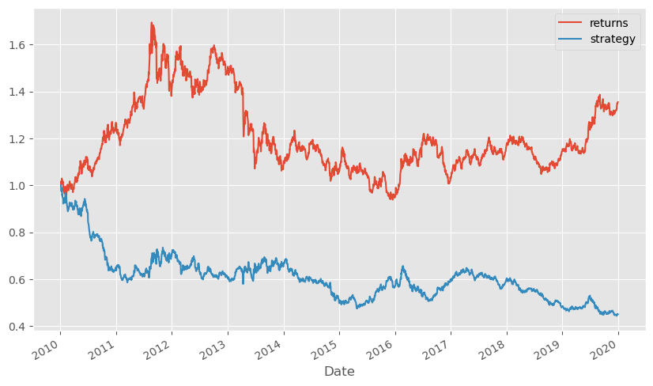

```python
data['position'] = np.where(data['returns']>0, 1, -1)
data['strategy'] = data['position'].shift(1) * data['returns']
data[['returns', 'strategy']].dropna().cumsum().apply(np.exp).plot(figsize=(10, 6));
```

使用滚动时间窗口 (在 **`Pandas`** 包中用函数 `rolling()` 实现)，时间序列动量策略可以推广到不仅仅是最后一期收益。例如，可以使用最后 2 和 3 个收益均值来生成买卖信号。下两图显示滚动 2 天情况下的策略表现比基准表现差，而滚动 3 天情况下的策略表现比基准表现好。

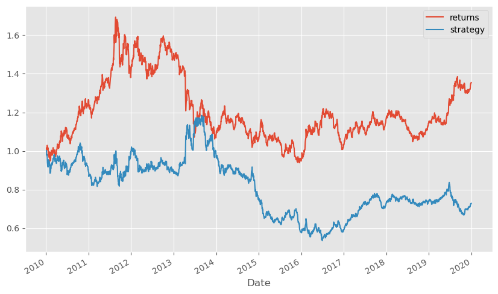

```python
data['position'] = np.where(data['returns'].rolling(2).mean()>0, 1, -1)
data['strategy'] = data['position'].shift(1) * data['returns']
data[['returns', 'strategy']].dropna().cumsum().apply(np.exp).plot(figsize=(10, 6));
```

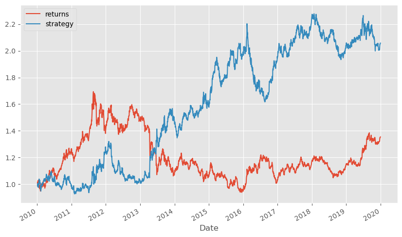

```python
data['position'] = np.where(data['returns'].rolling(3).mean()>0, 1, -1)
data['strategy'] = data['position'].shift(1) * data['returns']
data[['returns', 'strategy']].dropna().cumsum().apply(np.exp).plot(figsize=(10, 6));
```

除了日终数据，日内数据也可以使用时间序列动量。实际上，动量策略在日内比日终更常见。首先读取数据，AAPL 和 SPX 在 2020 年 5 月 5 日的分钟级别的数据。

```python
ticker = 'SPX' # 'AAPL'
data = pd.read_csv( ticker+'_1min_05052020.csv', index_col=0, parse_dates=True )
data.info()
```

```
<class 'pandas.core.frame.DataFrame'>
DatetimeIndex: 241 entries, 2020-05-05 16:00:00 to 2020-05-05 20:00:00
Data columns (total 5 columns):
 #   Column  Non-Null Count  Dtype
---  ------  --------------  -----
 0   HIGH    241 non-null    float64
 1   LOW     241 non-null    float64
 2   OPEN    241 non-null    float64
 3   CLOSE   241 non-null    float64
 4   COUNT   241 non-null    float64
dtypes: float64(5)
memory usage: 11.3 KB
```

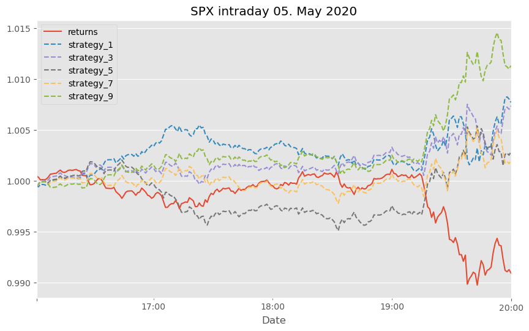

```python
data['returns'] = np.log(data['CLOSE'] / data['CLOSE'].shift(1))

to_plot = ['returns']

for m in [1, 3, 5, 7, 9]:
    data['position_%d' % m] = np.where(data['returns'].rolling(m).mean() > 0, 1, -1)
    data['strategy_%d' % m] = (data['position_%d' % m].shift(1) * data['returns'])
    to_plot.append('strategy_%d' % m)

data[to_plot].dropna().cumsum().apply(np.exp).plot( title=ticker+' intraday 05. May 2020',
                                                    figsize=(10, 6), style=['-', '--', '--', '--', '--', '--']);
```

### 2.2 通用示例

回到章首

上节代码可以解决实际问题，但是比较零散。本节将上节实施的函数整理成一个类，命名为 **`MomVectorBacktester`**，顾名思义用于对动量策略的向量化回测。该类的参数如下：

- `symbol`：RIC 代号
- `start`：要获取数据的开始日期
- `end`：要获取数据的结束日期
- `amount`：用于投资的初始金额
- `tc`：每笔交易的比例交易成本

与 **`SMAVectorBacktester`** 类相比，本类引入了两个重要的概括：在回测期开始时要投资的固定金额 `amount` 和成比例的交易成本 `tc`，以在成本方面更接近市场。特别是，在时间序列动量策略的背景下，考虑交易成本很重要，很多情况策略在不考虑交易成本回测是赚钱的，考虑后是亏钱的。

首先引入 `MomVectorBacktester` 赋予别名 `Mom`，在创建一个对象命名为 `mombt`。

### 零交易成本

先设置交易成本比例为 0。

```python
import MomVectorBacktester as Mom
mombt = Mom.MomVectorBacktester('XAU=', '2010-1-1', '2019-12-31', 10000, 0.0)
```

基于三天的时间窗口回测动量策略，发现策略优于基准回报。回测结果是个元组，第 1 个元素代表策略绝对收益额，第 2 个元素代表策略相对收益额。

```python
mombt.run_strategy(momentum=3)
```

```
(20554.41, 6993.33)
```

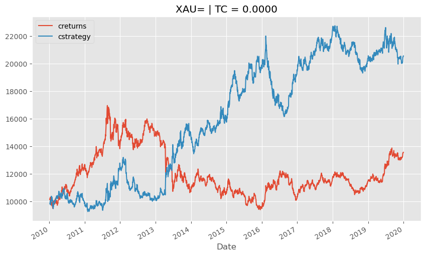

```python
mombt.plot_results()
```

### 有交易成本

再设置交易成本为 0.1%，运行回测发现策略收益比基准收益差。

```python
mombt = Mom.MomVectorBacktester('XAU=', '2010-1-1', '2019-12-31', 10000, 0.001)
```

```python
mombt.run_strategy(momentum=3)
```

```
(10612.95, -2948.12)
```

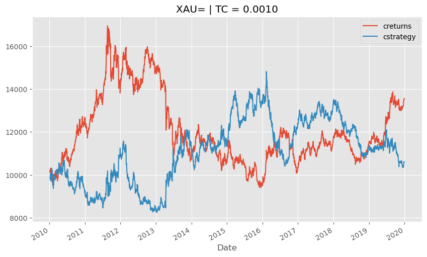

```python
mombt.plot_results()
```

# 3. 基于均值回归策略

回到目录

**均值回归** (mean reversion) 策略依赖于与动量策略相反的逻辑。最简单策略为

> 如果资产相对于其趋势表现“太好”，则会被做空，反之做多。

换句话说，虽然（时间序列）动量策略假设收益之间呈正相关，但均值回归策略假设收益呈负相关。

这里可以使用简单移动平均线 (SMA) 来量化“趋势”，对当前资产价格和 SMA 之间距离定义一个阈值 (threshold)，这标志着多头或空头头寸。

### 3.1 特殊示例

回到章首

本节两例针对两种挂钩黄金价格的资产，GLD 和 GDX，根据实证它们有显著的均值回归特征：

- GLD 是 SPDR Gold Shares 的代号，SPDR Gold Shares 是最大的实物黄金交易所交易基金 (ETF)，https://spdrgoldshares.com/
- GDX 是 VanEck Vectors Gold Miners ETF 的代号，该基金投资于股票产品以跟踪 NYSE Arca Gold Miners 指数，https://www.vaneck.com/?pagena=true

先看 GDX，并基于 25 天的 SMA 和 3.5 的阈值实施均值回归策略，当当前价格偏离 SMA 的绝对偏差以发出买卖信号。

下图显示了 GDX 和其 SMA 的当前价格之间的差异，以及分别生成卖出和买入信号的正负阈值：

```python
data = pd.DataFrame(raw['GDX'])
data.rename(columns={'GDX': 'price'}, inplace=True)
data['returns'] = np.log(data['price'] / data['price'].shift(1))
data
```

| Date | price | returns |
| --- | --- | --- |
| 2010-01-04 | 47.71 | NaN |
| 2010-01-05 | 48.17 | 0.009595 |
| 2010-01-06 | 49.34 | 0.023999 |
| 2010-01-07 | 49.10 | -0.004876 |
| 2010-01-08 | 49.84 | 0.014959 |
| ... | ... | ... |
| 2019-12-24 | 28.66 | 0.031546 |
| 2019-12-26 | 29.08 | 0.014548 |
| 2019-12-27 | 28.87 | -0.007248 |
| 2019-12-30 | 29.49 | 0.021248 |
| 2019-12-31 | 29.28 | -0.007147 |

2516 rows × 2 columns

设定 SMA 和阈值参数，在每个时点都计算当前价格和 SMA 的距离，并可视化距离和正负阈值，如下图所示。

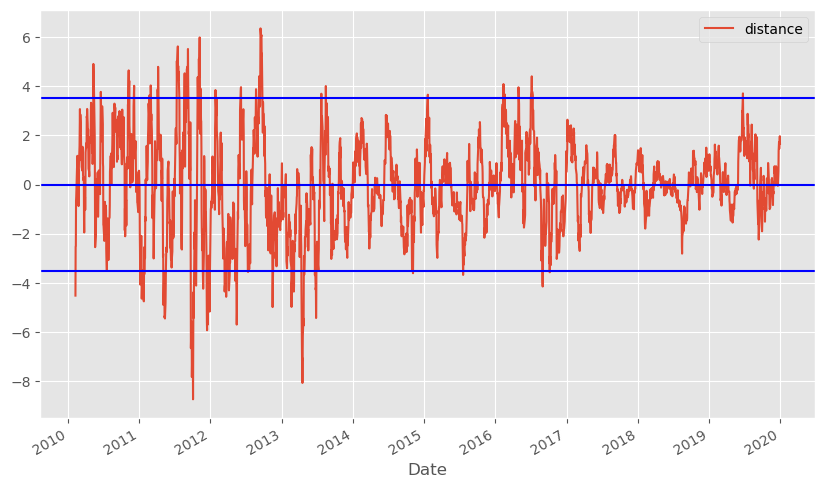

```python
SMA = 25
threshold = 3.5
data['SMA'] = data['price'].rolling(SMA).mean()
data['distance'] = data['price'] - data['SMA']

data['distance'].dropna().plot(figsize=(10, 6), legend=True)
plt.axhline(threshold, color='b')
plt.axhline(-threshold, color='b')
plt.axhline(0, color='b');
```

基于距离和阈值，可以生成交易信号：

- 如果距离值大于阈值，则做空（在 `position` 列设置 –1，否则设置 NaN）
- 如果距离值低于负阈值，则做多（在 `position` 列设置 1，否则不变）
- 如果距离值的符号有变化，则转到市场中性（在 `position` 列设置 0，否则不变）
- 用以前的值向前填充所有 NaN 位置； 将所有剩余的 NaN 值替换为 0

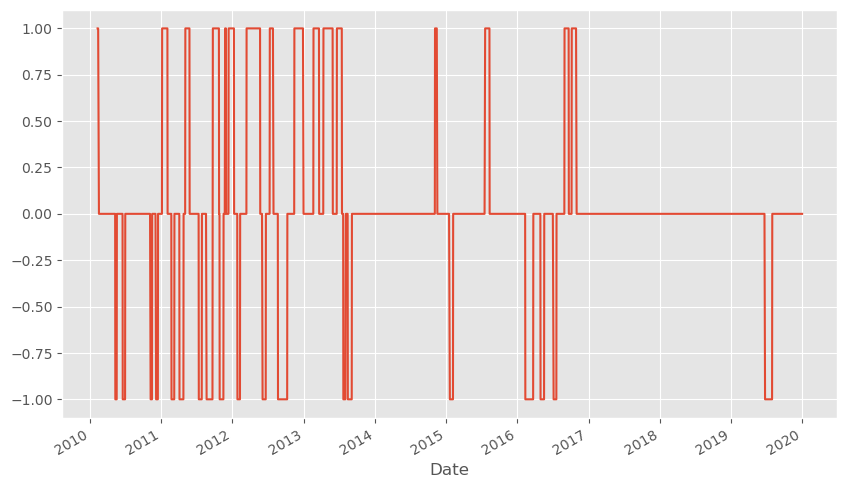

```python
data['position'] = np.where(data['distance'] > threshold, -1, np.nan)
data['position'] = np.where(data['distance'] < -threshold, 1, data['position'])
data['position'] = np.where(data['distance'] * data['distance'].shift(1) < 0, 0, data['position'])
data['position'] = data['position'].ffill().fillna(0)
data['position'].iloc[SMA:].plot(ylim=[-1.1, 1.1], figsize=(10, 6));
```

最后计算出策略收益。画图发现该策略的表现远远优于 GDX ETF，尽管特定的参数化导致长期持中性头寸（既不做多也不做空）。

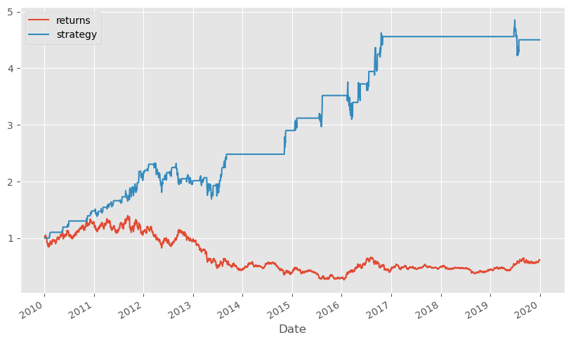

```python
data['strategy'] = data['position'].shift(1) * data['returns']
data[['returns', 'strategy']].dropna().cumsum().apply(np.exp).plot(figsize=(10, 6));
```

### 3.2 通用示例

回到章首

和以前一样，创建 **`MRVectorBacktester`** 类来做回测效率更高。该类继承 **`MomVectorBacktester`** 类，只是替换了 `run_strategy()` 方法以适应均值回归策略的具体情况。

该示例现在使用 GLD 并将比例交易成本设置为 0.1%，初始投资金额再次设置为 10,000 美元。

```python
import MRVectorBacktester as MR
mrbt = MR.MRVectorBacktester('GLD', '2010-1-1', '2019-12-31', 10000, 0.001)
```

设定参数 `SMA` 为 43，阈值 `threshold` 为7.5。下面结果和图显示了均值回归策略与 GLD ETF 相比的表现：

```python
mrbt.run_strategy(SMA=43, threshold=7.5)
```

```
(13542.15, 646.21)
```

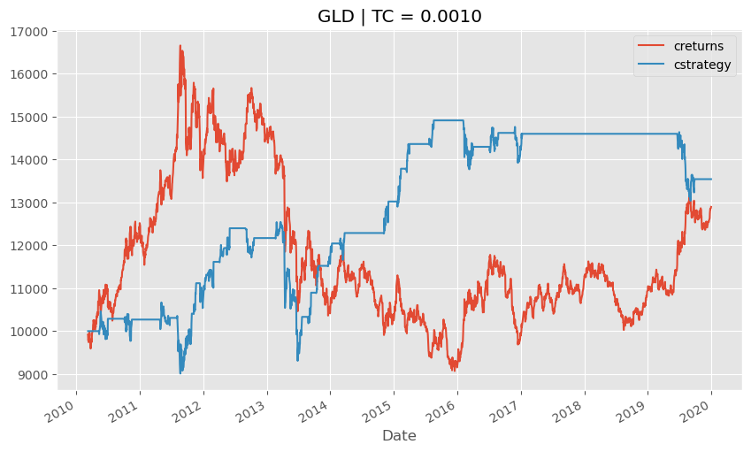

```python
mrbt.plot_results()
```